# Week 4 - Lectures & Quick Questions

Vishal Gupta

3/23/2019

```r
library(dplyr)
library(rpart)
library(rpart.plot)
library(caTools)
library(ROCR)
library(randomForest)
library(tm)
library(SnowballC)
```

## Judge, Jury, and Classifier: An Introduction to Trees

#### Video 4: CART in R

Loading the data

```r
stevens = read.csv("~/Downloads/stevens.csv")
str(stevens)
```

```
## 'data.frame':    566 obs. of  9 variables:
##  $ Docket    : Factor w/ 566 levels "00-1011","00-1045",..: 63 69 70 145 97 181 242 289 334 436 ...
##  $ Term      : int  1994 1994 1994 1994 1995 1995 1996 1997 1997 1999 ...
##  $ Circuit   : Factor w/ 13 levels "10th","11th",..: 4 11 7 3 9 11 13 11 12 2 ...
##  $ Issue     : Factor w/ 11 levels "Attorneys","CivilRights",..: 5 5 5 5 9 5 5 5 5 3 ...
##  $ Petitioner: Factor w/ 12 levels "AMERICAN.INDIAN",..: 2 2 2 2 2 2 2 2 2 2 ...
##  $ Respondent: Factor w/ 12 levels "AMERICAN.INDIAN",..: 2 2 2 2 2 2 2 2 2 2 ...
##  $ LowerCourt: Factor w/ 2 levels "conser","liberal": 2 2 2 1 1 1 1 1 1 1 ...
##  $ Unconst   : int  0 0 0 0 0 1 0 1 0 0 ...
##  $ Reverse   : int  1 1 1 1 1 0 1 1 1 1 ...
```

Splitting the data into Test and Train

```r
library(caTools)
set.seed(3000)
spl = sample.split(stevens$Reverse, SplitRatio = 0.7)
Train = stevens[spl==T,]
Test = stevens[spl==F,]
```

Installing - `rpart` : Recursive Partitioning and Regression Trees - `rpart.plot` : Plot an rpart model. A simplified interface to the prp function

```r
#install.packages("rpart")
library(rpart)
#install.packages("rpart.plot")
library(rpart.plot)
```

Training a CART model to predict if Supreme Court will “Reverse” the decision

```r
StevensTree = rpart(Reverse ~ Circuit + Issue + Petitioner + Respondent + LowerCourt + Unconst, data = Train, method="class", minbucket=25)
```

Plotting `StevensTree`

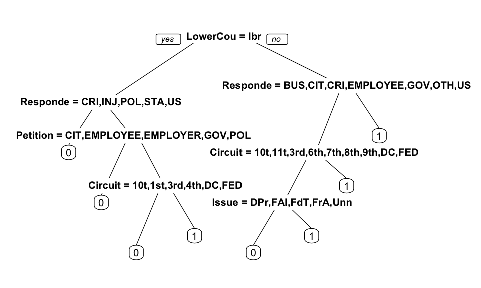

```r
prp(StevensTree)
```

Predict reversal of cases in test set

```r
PredictCART = predict(StevensTree, newdata = Test, type = "class")
table(Test$Reverse, PredictCART)
```

```
##    PredictCART
##      0  1
##   0 41 36
##   1 22 71
```

Plotting ROC Curve Note : - If `type="class"` is not specified, then `predict` returns probabilities of both classes. - `PredictROC[,2]` gives probability of output being `1`

```r
library(ROCR)
PredictROC = predict(StevensTree, newdata = Test)
head(PredictROC)
```

```
##            0         1
## 1  0.3035714 0.6964286
## 3  0.3035714 0.6964286
## 4  0.4000000 0.6000000
## 6  0.4000000 0.6000000
## 8  0.4000000 0.6000000
## 21 0.3035714 0.6964286
```

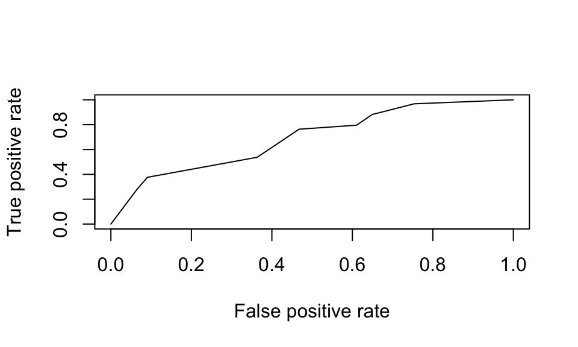

```r
pred = prediction(PredictROC[,2], Test$Reverse)
perf = performance(pred, "tpr", "fpr")
plot(perf)
```

#### Quick Question

**Compute the AUC of the CART model from the previous video**

```r
as.numeric(performance(pred, "auc")@y.values)
```

```
## [1] 0.6927105
```

Now, recall that in Video 4, our tree had 7 splits. **Let’s see how this changes if we change the value of minbucket.**

First **build a CART model that is similar to the one we built in Video 4, except change the minbucket parameter to 5.** Plot the tree.

**How many splits does the tree have?**

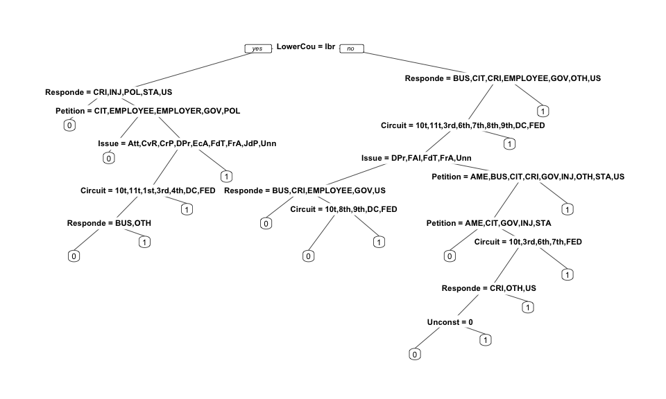

```r
stevensTree5 = rpart(Reverse ~ Circuit + Issue + Petitioner + Respondent + LowerCourt + Unconst,data = Train ,method = "class",minbucket=5)
prp(stevensTree5)
```

Now build a CART model that is similar to the one we built in Video 4, except **change the minbucket parameter to 100**. Plot the tree.

**How many splits does the tree have?**

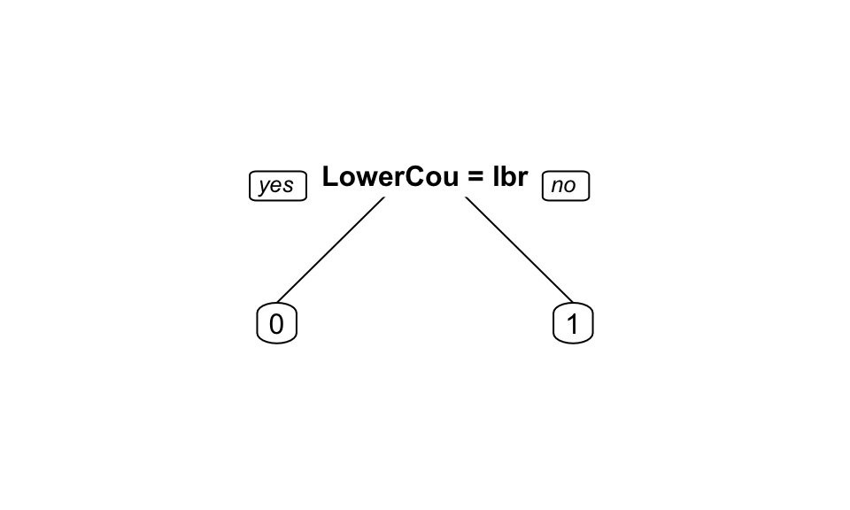

```r
stevensTree100 = rpart(Reverse ~ Circuit + Issue + Petitioner + Respondent + LowerCourt + Unconst,data = Train ,method = "class",minbucket=100)
prp(stevensTree100)
```

#### Video 5: Random Forests

Install packages

- randomForest : Classification and Regression with Random Forest

```r
#install.packages("randomForest")
library(randomForest)
```

Encode `Reverse` as a factor

```r
Train$Reverse = as.factor(Train$Reverse)
Test$Reverse = as.factor(Test$Reverse)
```

Training a Random Forest model to predict reversal

```r
StevensForest = randomForest(Reverse ~ Circuit + Issue + Petitioner + Respondent + LowerCourt + Unconst, data = Train, ntree=200, nodesize=25)
```

Predict outcomes of cases in test set using `StevensForest`

```r
PredictForest = predict(StevensForest, newdata = Test)
table(Test$Reverse, PredictForest)
```

```
##    PredictForest
##      0  1
##   0 43 34
##   1 20 73
```

#### Quick Question

When creating random forest models, you might still get different answers from the ones you see here even if you set the random seed. This has to do with different operating systems and the random forest implementation.

**Let’s see what happens if we set the seed to two different values and create two different random forest models.**

First, **set the seed to 100**, and the re-build the random forest model, exactly like we did in the previous video (Video 5). Then make predictions on the test set. **What is the accuracy of the model on the test set?**

```r
set.seed(100)
spl = sample.split(stevens$Reverse,SplitRatio = 0.7)
Train = stevens[spl==T,]
Test = stevens[spl==F,]
Test$Reverse = as.factor(Test$Reverse)
Train$Reverse = as.factor(Train$Reverse)
stevensForest = randomForest(Reverse ~ Circuit + Issue + Petitioner + Respondent + LowerCourt + Unconst,data = Train,nodesize=25,ntree=200)
pred = predict(stevensForest,Test)
sum(pred==Test$Reverse)/length(Test$Reverse)
```

```
## [1] 0.7
```

Now, **set the seed to 200**, and then re-build the random forest model, exactly like we did in the previous video (Video 5). Then make predictions on the test set. **What is the accuracy of this model on the test set?**

```r
set.seed(200)
spl = sample.split(stevens$Reverse,SplitRatio = 0.7)
Train = stevens[spl==T,]
Test = stevens[spl==F,]
Test$Reverse = as.factor(Test$Reverse)
Train$Reverse = as.factor(Train$Reverse)
stevensForest = randomForest(Reverse ~ Circuit + Issue + Petitioner + Respondent + LowerCourt + Unconst,data = Train,nodesize=25,ntree=200)
pred = predict(stevensForest,Test)
sum(pred==Test$Reverse)/length(Test$Reverse)
```

```
## [1] 0.6470588
```

#### Video 7: Cross-Validation

Install packages

```r
#install.packages("caret")
library(caret)
#install.packages("e1071")
library(e1071)
```

Define No. of Folds for Cross-Validation and grid space to iterate over.

```r
numFolds = trainControl( method = "cv", number = 10 )
cpGrid = expand.grid( .cp = seq(0.01,0.5,0.01))
```

Perform Cross-Validation for `numFolds` folds over `cpGrid` on `rpart`

```r
train(Reverse ~ Circuit + Issue + Petitioner + Respondent + LowerCourt + Unconst, data = Train, method = "rpart", trControl = numFolds, tuneGrid = cpGrid )
```

```
## CART
##
## 396 samples
##   6 predictor
##   2 classes: '0', '1'
##
## No pre-processing
## Resampling: Cross-Validated (10 fold)
## Summary of sample sizes: 357, 356, 357, 356, 356, 356, ...
## Resampling results across tuning parameters:
##
##   cp    Accuracy   Kappa
##   0.01  0.6416667  0.26816832
##   0.02  0.6416026  0.27132836
##   0.03  0.6493590  0.29534522
##   0.04  0.6621154  0.32311729
##   0.05  0.6621154  0.32311729
##   0.06  0.6621154  0.32311729
##   0.07  0.6621154  0.32311729
##   0.08  0.6621154  0.32311729
##   0.09  0.6621154  0.32311729
##   0.10  0.6621154  0.32311729
##   0.11  0.6621154  0.32311729
##   0.12  0.6621154  0.32311729
##   0.13  0.6621154  0.32311729
##   0.14  0.6621154  0.32311729
##   0.15  0.6621154  0.32311729
##   0.16  0.6621154  0.32311729
##   0.17  0.6621154  0.32311729
##   0.18  0.6621154  0.32311729
##   0.19  0.6621154  0.32311729
##   0.20  0.6621154  0.32311729
##   0.21  0.6621154  0.32311729
##   0.22  0.6621154  0.32311729
##   0.23  0.6390385  0.26973083
##   0.24  0.5980128  0.17129953
##   0.25  0.5805128  0.12713710
##   0.26  0.5580128  0.06312694
##   0.27  0.5580128  0.06312694
##   0.28  0.5453846  0.01262136
```

[output cut: 10 more lines]

```
##   0.39  0.5453846  0.00000000
##   0.40  0.5453846  0.00000000
##   0.41  0.5453846  0.00000000
##   0.42  0.5453846  0.00000000
##   0.43  0.5453846  0.00000000
##   0.44  0.5453846  0.00000000
##   0.45  0.5453846  0.00000000
##   0.46  0.5453846  0.00000000
##   0.47  0.5453846  0.00000000
##   0.48  0.5453846  0.00000000
##   0.49  0.5453846  0.00000000
##   0.50  0.5453846  0.00000000
##
## Accuracy was used to select the optimal model using the largest value.
## The final value used for the model was cp = 0.22.
```

Create a CART model with `cp = 0.18`

```r
StevensTreeCV = rpart(Reverse ~ Circuit + Issue + Petitioner + Respondent + LowerCourt + Unconst, data = Train, method="class", cp = 0.18)
```

Predict outcomes of test cases

```r
PredictCV = predict(StevensTreeCV, newdata = Test, type = "class")
sum(Test$Reverse==PredictCV)/length(PredictCV)
```

```
## [1] 0.6823529
```

#### Quick Question

**Plot the tree that we created using cross-validation. How many splits does it have?**

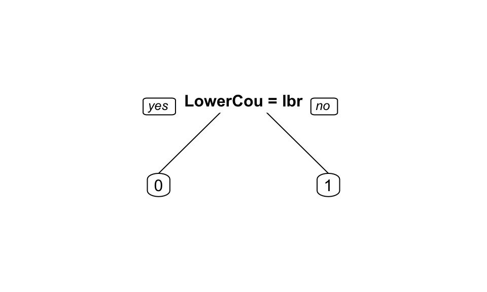

```r
prp(StevensTreeCV)
```

## Keeping an Eye on Healthcare Costs: The D2Hawkeye Story

Loading the data

```r
Claims = read.csv("~/Downloads/ClaimsData.csv")
str(Claims)
```

```
## 'data.frame':    458005 obs. of  16 variables:
##  $ age              : int  85 59 67 52 67 68 75 70 67 67 ...
##  $ alzheimers       : int  0 0 0 0 0 0 0 0 0 0 ...
##  $ arthritis        : int  0 0 0 0 0 0 0 0 0 0 ...
##  $ cancer           : int  0 0 0 0 0 0 0 0 0 0 ...
##  $ copd             : int  0 0 0 0 0 0 0 0 0 0 ...
##  $ depression       : int  0 0 0 0 0 0 0 0 0 0 ...
##  $ diabetes         : int  0 0 0 0 0 0 0 0 0 0 ...
##  $ heart.failure    : int  0 0 0 0 0 0 0 0 0 0 ...
##  $ ihd              : int  0 0 0 0 0 0 0 0 0 0 ...
##  $ kidney           : int  0 0 0 0 0 0 0 0 0 0 ...
##  $ osteoporosis     : int  0 0 0 0 0 0 0 0 0 0 ...
##  $ stroke           : int  0 0 0 0 0 0 0 0 0 0 ...
##  $ reimbursement2008: int  0 0 0 0 0 0 0 0 0 0 ...
##  $ bucket2008       : int  1 1 1 1 1 1 1 1 1 1 ...
##  $ reimbursement2009: int  0 0 0 0 0 0 0 0 0 0 ...
##  $ bucket2009       : int  1 1 1 1 1 1 1 1 1 1 ...
```

Percentage of patients in each cost bucket

```r
table(Claims$bucket2009)/nrow(Claims)
```

```
##
##           1           2           3           4           5
## 0.671267781 0.190170413 0.089466272 0.043324855 0.005770679
```

Split the data into Train and Test

```r
library(caTools)
set.seed(88)
spl = sample.split(Claims$bucket2009, SplitRatio = 0.6)
ClaimsTrain = Claims[spl==T,]
ClaimsTest = Claims[spl==F,]
```

#### Quick Question

What is the average age of patients in the training set, ClaimsTrain?

```r
mean(ClaimsTrain$age)
```

```
## [1] 72.63773
```

What proportion of people in the training set (ClaimsTrain) had at least one diagnosis code for diabetes?

```r
sum(ClaimsTrain$diabetes)/nrow(ClaimsTrain)
```

```
## [1] 0.3808983
```

#### Video 7: Baseline Method and Penalty Matrix

Baseline Model Accuracy

```r
table(ClaimsTest$bucket2009,ClaimsTest$bucket2008)
```

```
##
##          1      2      3      4      5
##   1 110138   7787   3427   1452    174
##   2  16000  10721   4629   2931    559
##   3   7006   4629   2774   1621    360
##   4   2688   1943   1415   1539    352
##   5    293    191    160    309    104
```

```r
sum(ClaimsTest$bucket2009==ClaimsTest$bucket2008)/nrow(ClaimsTest)
```

```
## [1] 0.6838135
```

Creating Penalty Matrix

```r
PenaltyMatrix = matrix(c(0,1,2,3,4,2,0,1,2,3,4,2,0,1,2,6,4,2,0,1,8,6,4,2,0), byrow=TRUE, nrow=5)
```

Penalty on Baseline Model

Calculating Penalty of Baseline Model

```r
as.matrix(table(ClaimsTest$bucket2009, ClaimsTest$bucket2008))*PenaltyMatrix
```

```
##
##         1     2     3     4     5
##   1     0  7787  6854  4356   696
##   2 32000     0  4629  5862  1677
##   3 28024  9258     0  1621   720
##   4 16128  7772  2830     0   352
##   5  2344  1146   640   618     0
```

```r
sum(as.matrix(table(ClaimsTest$bucket2009, ClaimsTest$bucket2008))*PenaltyMatrix)/nrow(ClaimsTest)
```

```
## [1] 0.7386055
```

#### Quick Question

Suppose that instead of the baseline method discussed in the previous video, we used the baseline method of predicting the most frequent outcome for all observations. **This new baseline method would predict cost bucket 1 for everyone.**

What would the accuracy of this baseline method be on the test set?

```r
pred_ones = rep(1,nrow(ClaimsTest))
sum(ClaimsTest$bucket2009==pred_ones)/nrow(ClaimsTest)
```

```
## [1] 0.67127
```

```r
sum(as.matrix(table(ClaimsTest$bucket2009,pred_ones))*PenaltyMatrix[,1])/nrow(ClaimsTest)
```

```
## [1] 1.044301
```